# Assignment 3

Atakan Demirkan

6 Haziran 2021

# Introduction & Problem Description

The aim of this study to predict tomorrow’s hourly electricity consumption of Turkey. The data is downloaded from [EPIAS](https://seffaflik.epias.com.tr/transparency/tuketim/gerceklesen-tuketim/gercek-zamanli-tuketim.xhtml). The time range is 01.01.2016-20.05.2021.

## Preparing and Adjustments

### Required Libraries

Firstly, I loaded required libraries

```r
library(readxl)
library(zoo)
library(lubridate)
library(scales)
library(data.table)
library(tidyverse)
library(urca)
library(tsibble)
library(forecast)
```

### Reading Data

I download the data via read.csv function.

```r
raw_data <- read.csv("C:\\Users\\aadem\\OneDrive\\Desktop\\ConsumptionData.csv")
head(raw_data)
```

```
##         Date  Hour Consumption..MWh.
## 1 01.01.2016 00:00         26,277.24
## 2 01.01.2016 01:00         24,991.82
## 3 01.01.2016 02:00         23,532.61
## 4 01.01.2016 03:00         22,464.78
## 5 01.01.2016 04:00         22,002.91
## 6 01.01.2016 05:00         21,957.08
```

```r
hourly_data <- raw_data %>%
  mutate(date_hour=paste(Date,Hour,sep = " ")) %>%
  mutate(date=as.POSIXct(date_hour,format="%d.%m.%Y %H:%M"),consumption=as.numeric(gsub(",","",Consumption..MWh.))) %>%
  select(date,consumption)
```

### Visual Analysis

To reach a better understand about the data, we should plot it.

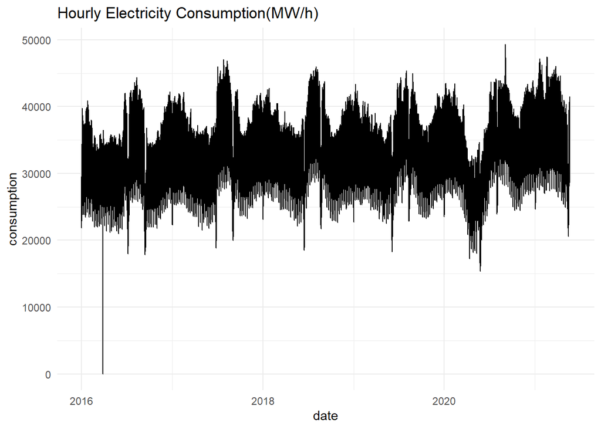

```r
ggplot(hourly_data,aes(x=date,y=consumption))+
  geom_line()+
  theme_minimal()+
  labs(title="Hourly Electricity Consumption(MW/h)")
```

The first thing that caught my eye is that there is a 0 consumption value in 2016, This null value may prevent making healthy analyzes. So, I should assign a new logical value to this row. Taking average of previous and next hour seems to be logical.

```r
i <- which.min(hourly_data$consumption)
hourly_data[i,'consumption'] <- mean(c(hourly_data[i-1,'consumption'],hourly_data[i+1,'consumption']))
```

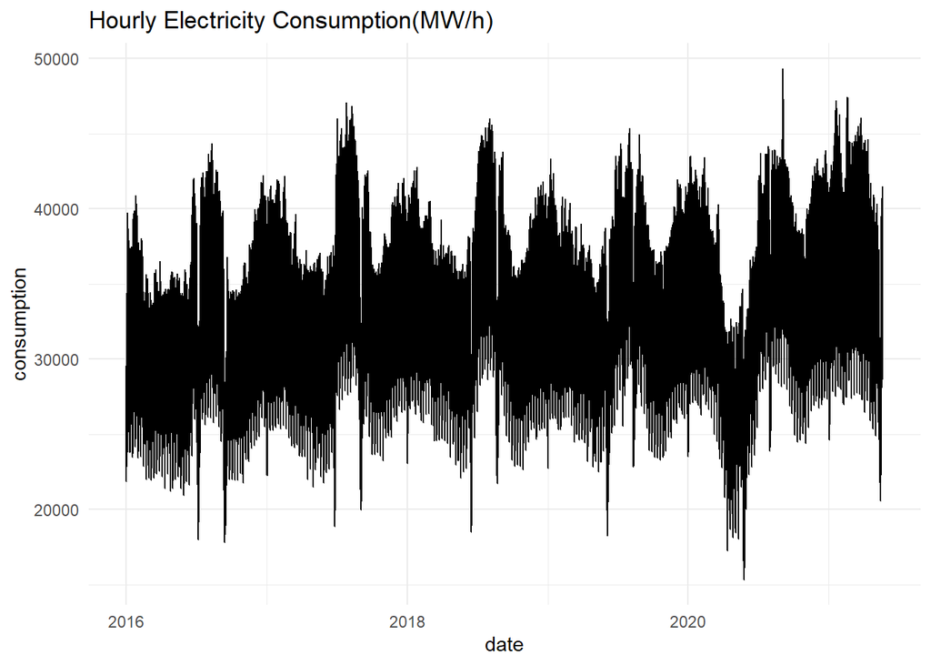

```r
ggplot(hourly_data,aes(x=date,y=consumption))+
  geom_line()+
  theme_minimal()+
  labs(title="Hourly Electricity Consumption(MW/h)")
```

When we check the data visually, we see an increased use of electricity during the summer months. In addition, due to reasons that are caused by pandemic, electricity consumption deviated from normal levels in the spring of 2020. And finally, there were sudden deviations in some periods. Religious and public holidays may have caused this situation. According to the data published by EPİAŞ on a profile basis, the high share of commercial and industrial enterprises in electricity consumption makes this situation logical.

As a result, it’s hard to say data is stationary according to visual testing.However, it is necessary to prove this comment with more quantitative methods.So, we can plot autocorrelation function.

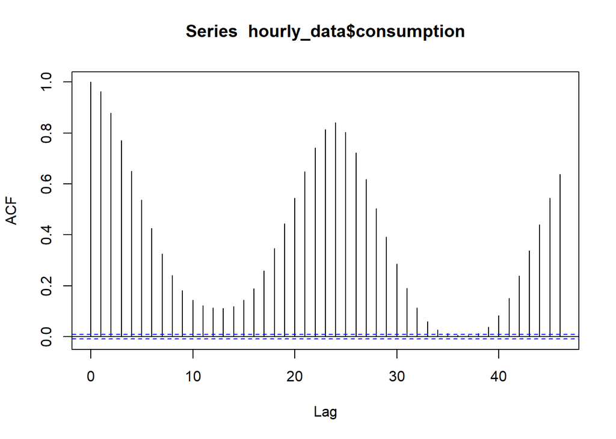

```r
acf(hourly_data$consumption)
```

We see a very high autocorrelation. Thus, the results of the autocorrelation function and the results of the visual analysis were compatible.

### Time Frame Adjustments

The time frame in the original data source is specified as hourly.However, I will use data from multiple time frames in analysis. So, I created data in multiple time frame before starting analysis.

```r
daily_data <- hourly_data %>%
  group_by(date(date)) %>%
  summarise(consumption=mean(consumption)) %>%
  rename(date='date(date)')
```

```r
weekly_data <- daily_data %>%
  group_by(yearweek(date)) %>%
  summarise(consumption=mean(consumption)) %>%
  rename(yearweek='yearweek(date)')
```

```r
monthly_data <- daily_data %>%
  group_by(yearmonth(date)) %>%
  summarise(consumption=mean(consumption)) %>%
  rename(month='yearmonth(date)')
```

# Task 1- Decomposition

## Hourly Level

```r
ts_hourly_data <- ts(hourly_data$consumption, frequency = 24)
```

When we visually check the data in hourly basis, we decided that additive model would be a greater choice for this time series rather than multiplicative. We should decompose the data into trend, seasonal, remainder component via decompose function.

Let’s use `decompose()` function to decompose the series into trend, seasonal, and random component.

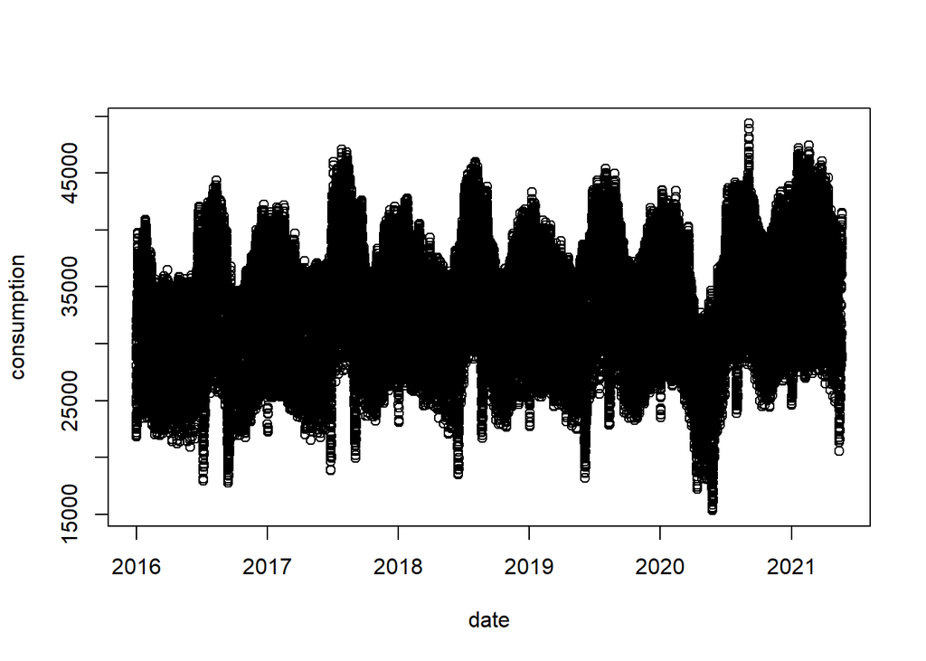

```r
decomposed_hourly_data <- decompose(ts_hourly_data, type="additive")
plot(hourly_data)
```

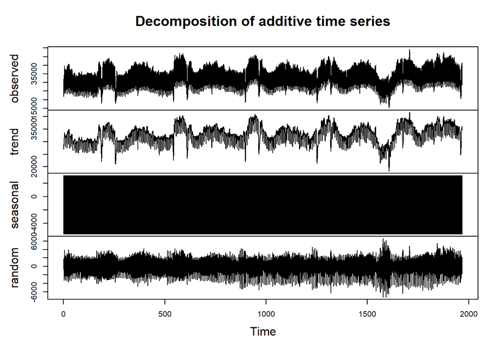

```r
plot(decomposed_hourly_data)
```

## Daily Level

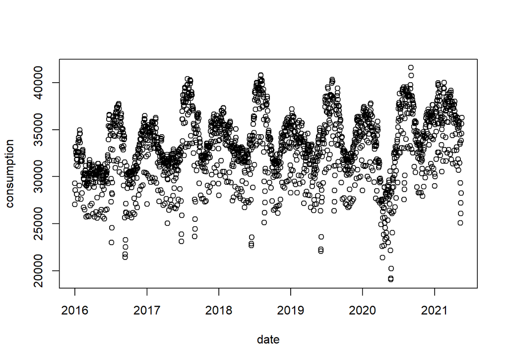

```r
plot(daily_data)
```

Visually, one can talk about seasonality in daily data.

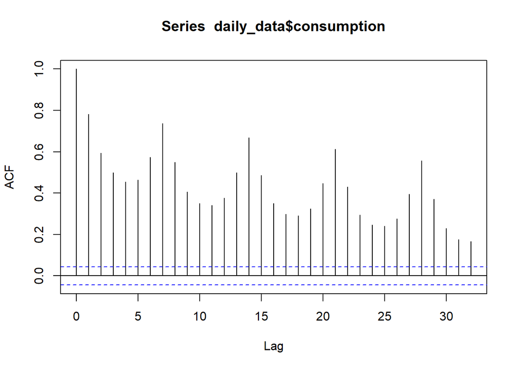

```r
acf(daily_data$consumption)
```

There is a seasonality in lag=7.

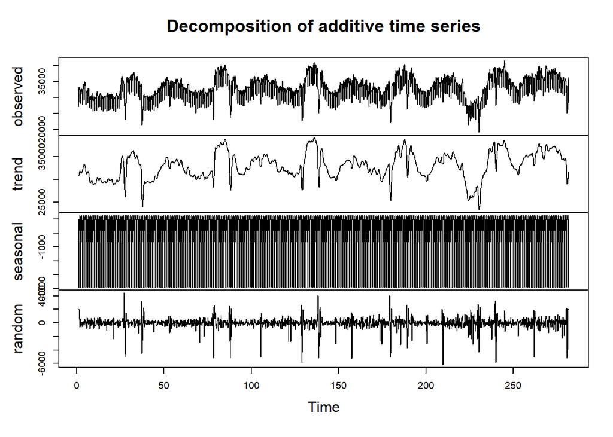

```r
ts_daily_data <- ts(daily_data$consumption, frequency = 7)
decomposed_daily_data <- decompose(ts_daily_data, type = "additive")
plot(decomposed_daily_data)
```

## Weekly Level

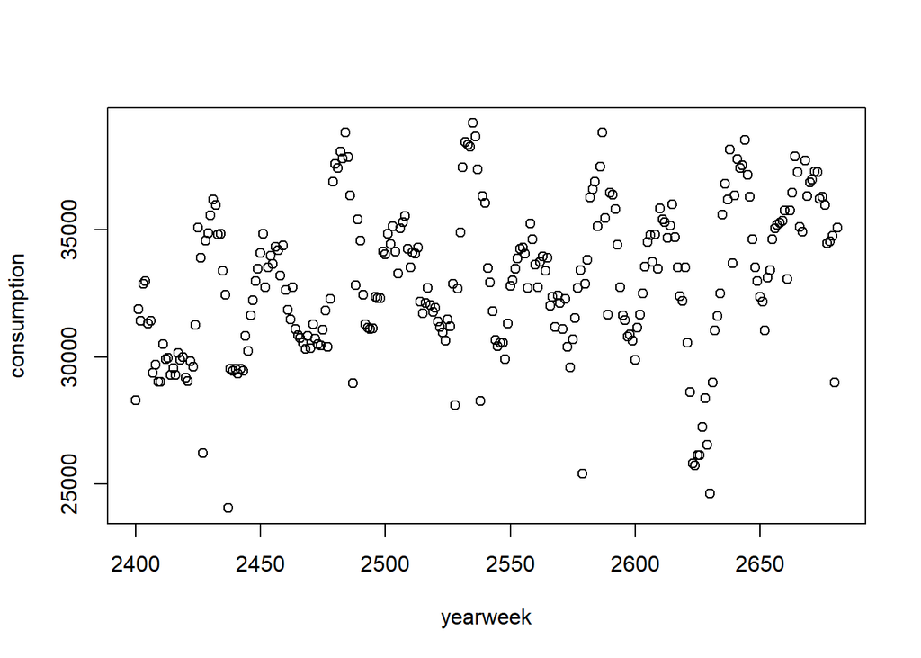

```r
plot(weekly_data)
```

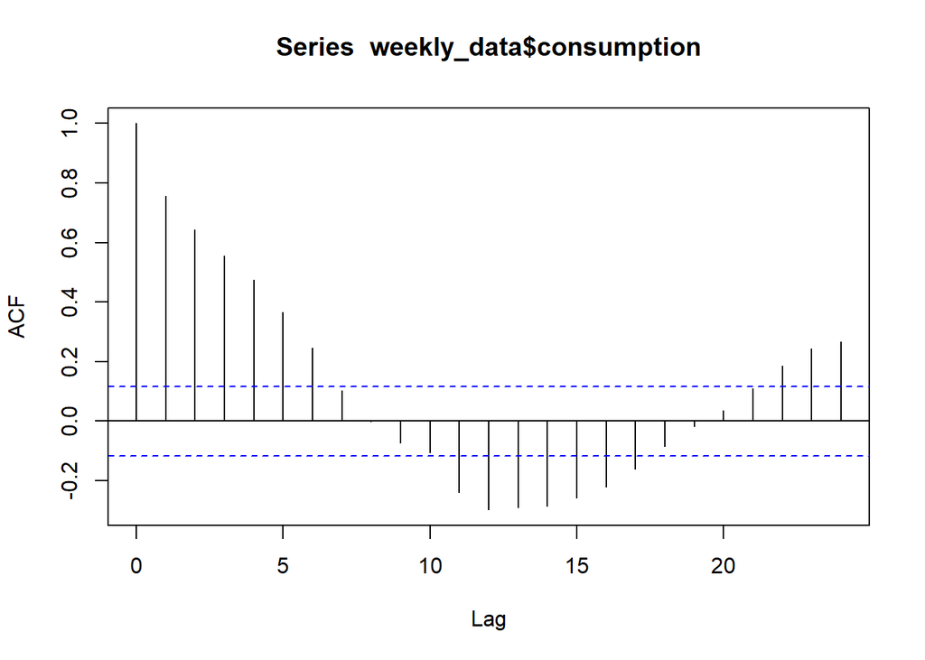

```r
acf(weekly_data$consumption)
```

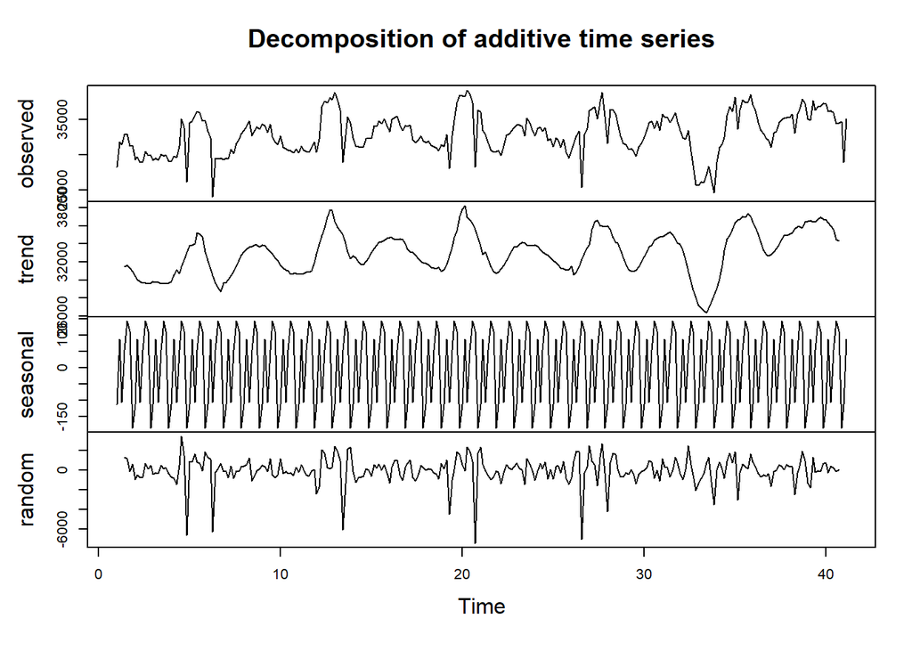

```r
ts_weekly_data <- ts(weekly_data$consumption, frequency = 7)
decomposed_weekly_data <- decompose(ts_weekly_data, type = "additive")
plot(decomposed_weekly_data)
```

## Monthly Level

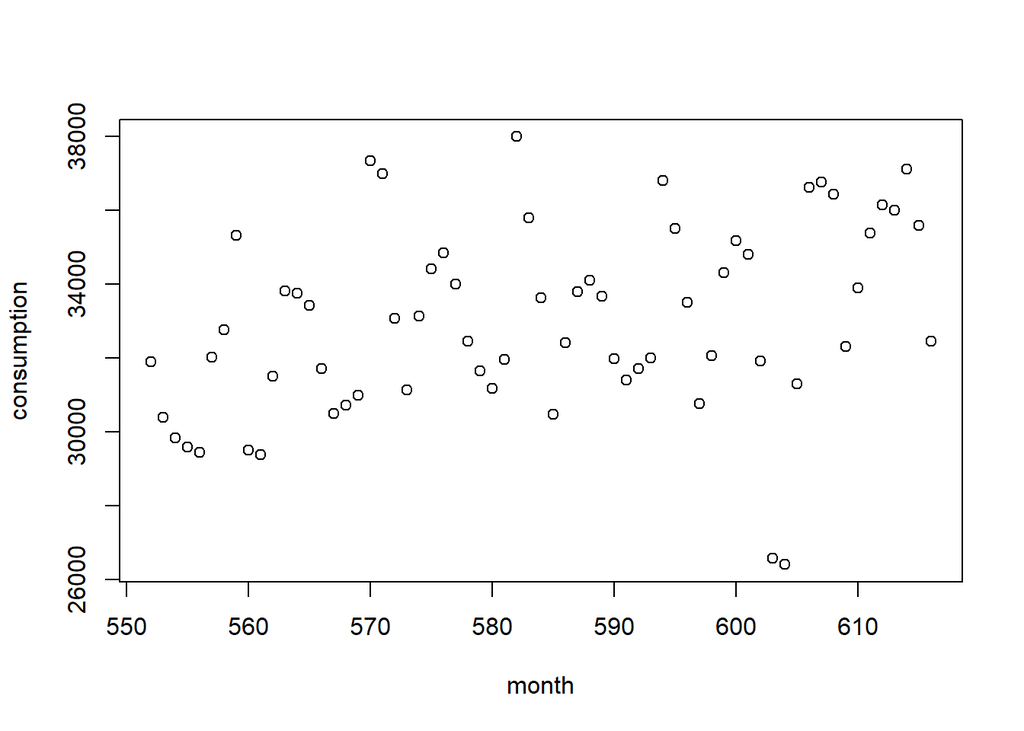

```r
plot(monthly_data)
```

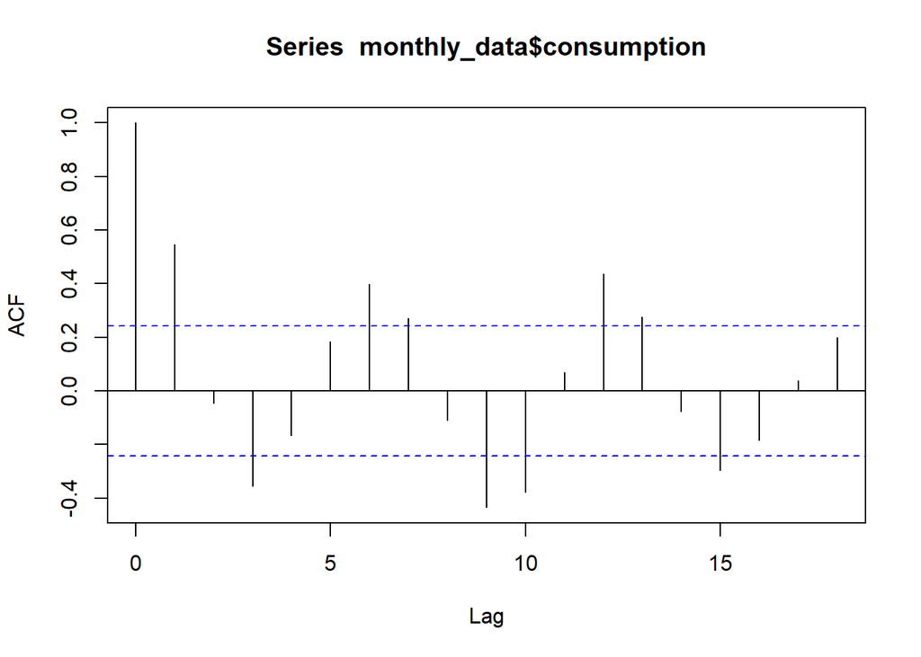

```r
acf(monthly_data$consumption)
```

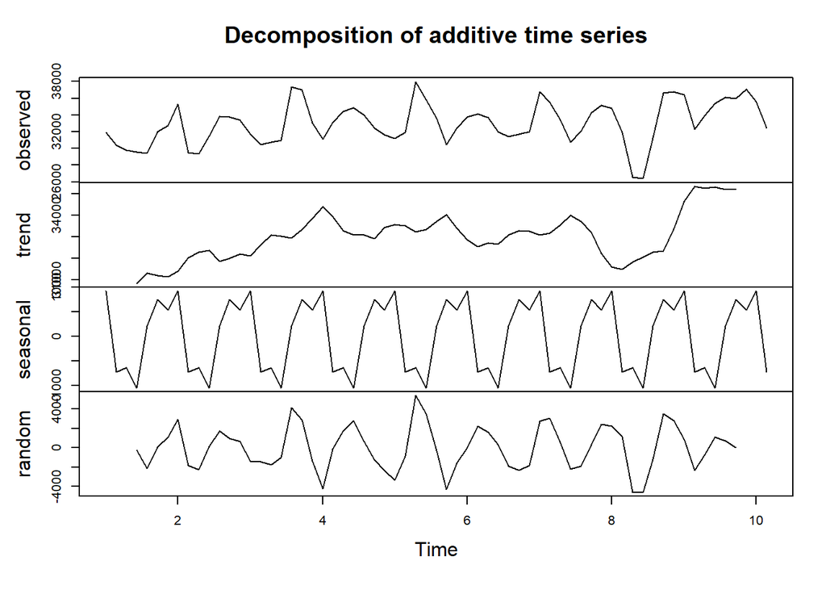

```r
ts_monthly_data <- ts(monthly_data$consumption, frequency = 7)
decomposed_monthly_data <- decompose(ts_monthly_data, type = "additive")
plot(decomposed_monthly_data)
```

# Task 2

For rest of this report, we will continue with the decomposed data with frequency=(7*24).That is we think that both the hour and the day of the observation define the seasonality of our data.

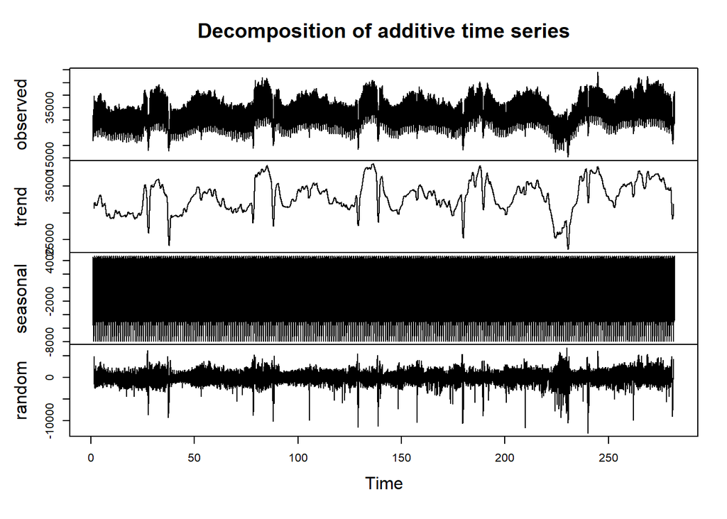

```r
ts_hd <- ts(hourly_data$consumption, frequency = 24*7)
decomposed_hd <- decompose(ts_hd, type = "additive")
plot(decomposed_hd)
```

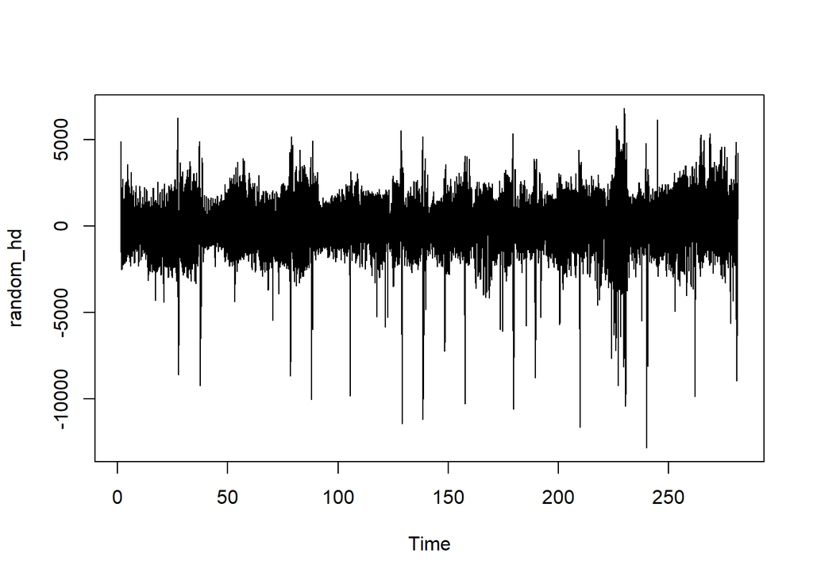

```r
random_hd <- decomposed_hd$random
plot(random_hd)
```

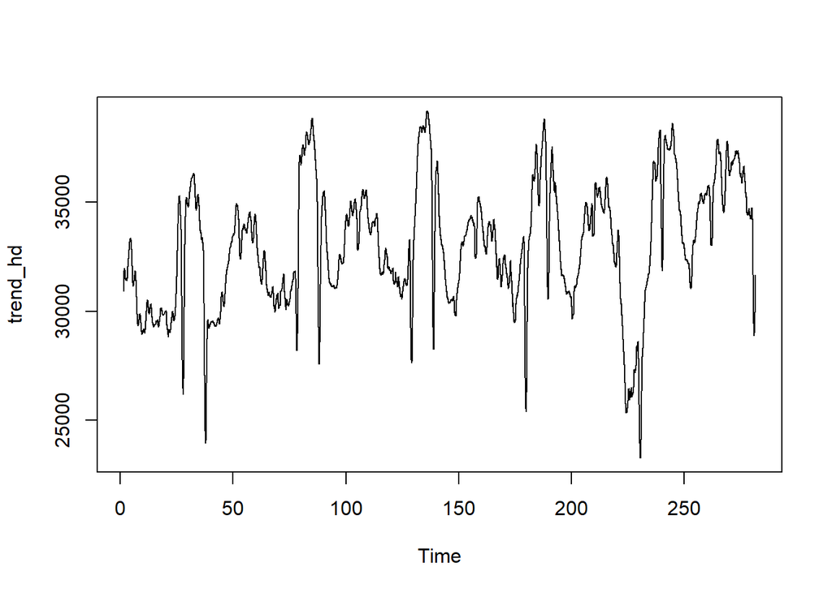

```r
trend_hd <- decomposed_hd$trend
plot(trend_hd)
```

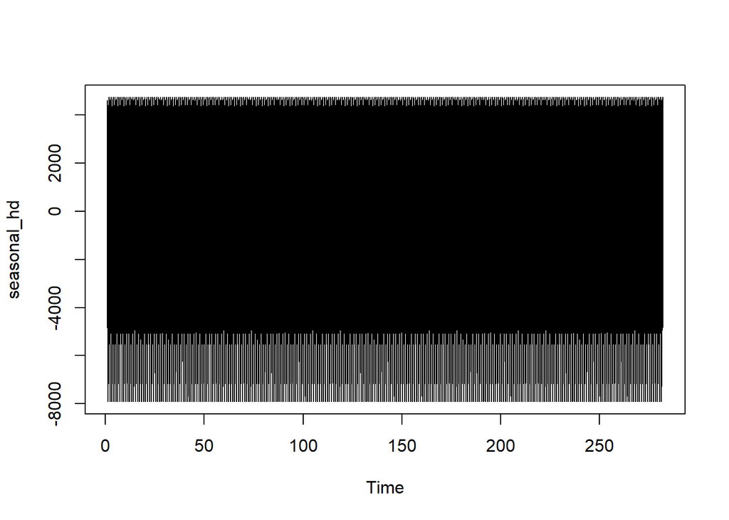

```r
seasonal_hd <- decomposed_hd$seasonal
plot(seasonal_hd)
```

Random part satisfies the assumptions that it follows 0 mean and constant variance. Also, We can see a seasonality in trend.

# Task 3 (AR Models)

I should deseasonalize and detrend my data.

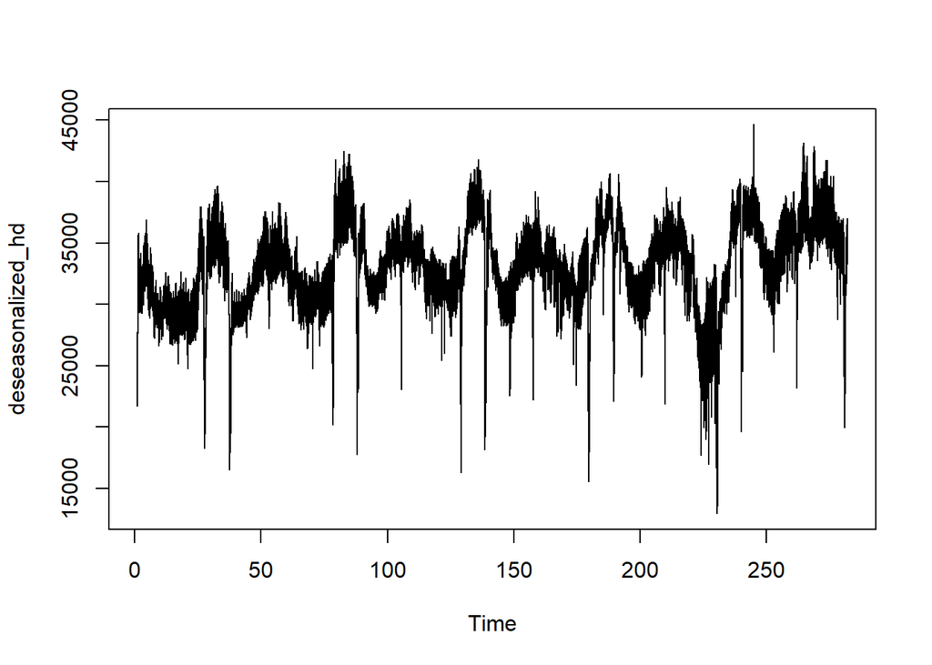

```r
deseasonalized_hd <- ts_hd-decomposed_hd$seasonal
plot(deseasonalized_hd)
```

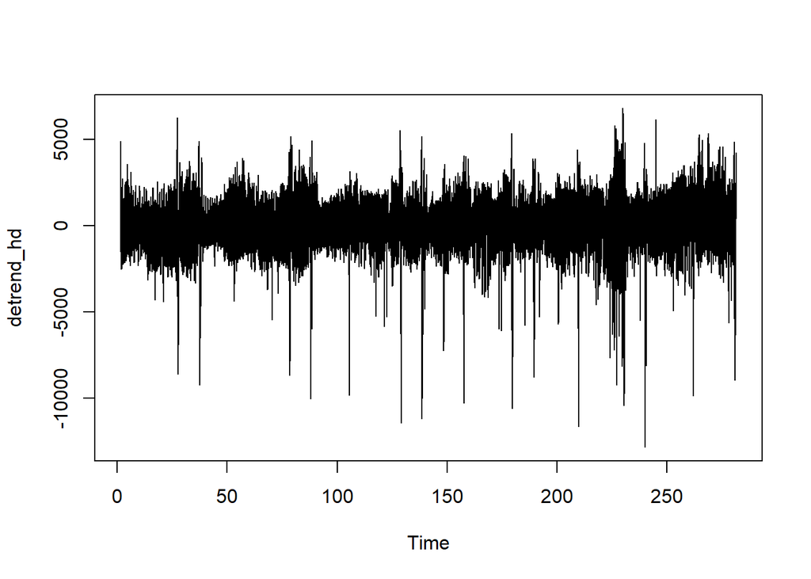

```r
detrend_hd <- deseasonalized_hd-decomposed_hd$trend
ts.plot(detrend_hd)
```

I try to find best AR model.

```r
ar_model = arima(random_hd, order=c(1,0,0))
ar_model
```

```
##
## Call:
## arima(x = random_hd, order = c(1, 0, 0))
##
## Coefficients:
##          ar1  intercept
##       0.9236    -1.0772
## s.e.  0.0018    34.2837
##
## sigma^2 estimated as 322651:  log likelihood = -365083.2,  aic = 730172.4
```

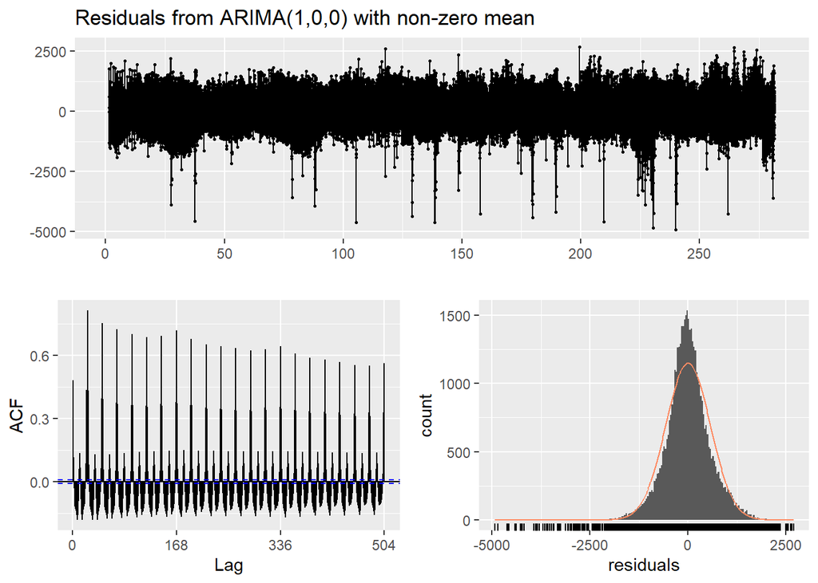

```
##
##  Ljung-Box test
##
## data:  Residuals from ARIMA(1,0,0) with non-zero mean
## Q* = 673305, df = 334, p-value < 2.2e-16
##
## Model df: 2.   Total lags used: 336
```

```r
checkresiduals(ar_model)
```

```r
ar_model2 = arima(random_hd, order=c(2,0,0))
ar_model2
```

```
##
## Call:
## arima(x = random_hd, order = c(2, 0, 0))
##
## Coefficients:
##          ar1      ar2  intercept
##       1.4047  -0.5215    -1.0783
## s.e.  0.0039   0.0039    19.1362
##
## sigma^2 estimated as 234926:  log likelihood = -357620.6,  aic = 715249.2
```

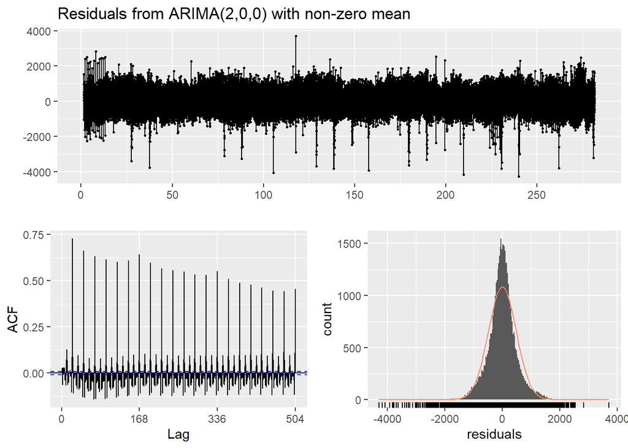

```
##
##  Ljung-Box test
##
## data:  Residuals from ARIMA(2,0,0) with non-zero mean
## Q* = 298111, df = 333, p-value < 2.2e-16
##
## Model df: 3.   Total lags used: 336
```

```r
checkresiduals(ar_model2)
```

```r
ar_model3 = arima(random_hd, order=c(3,0,0))
ar_model3
```

```
##
## Call:
## arima(x = random_hd, order = c(3, 0, 0))
##
## Coefficients:
##          ar1      ar2     ar3  intercept
##       1.4345  -0.6019  0.0572    -1.0785
## s.e.  0.0046   0.0076  0.0046    20.2544
##
## sigma^2 estimated as 234157:  log likelihood = -357543.5,  aic = 715097
```

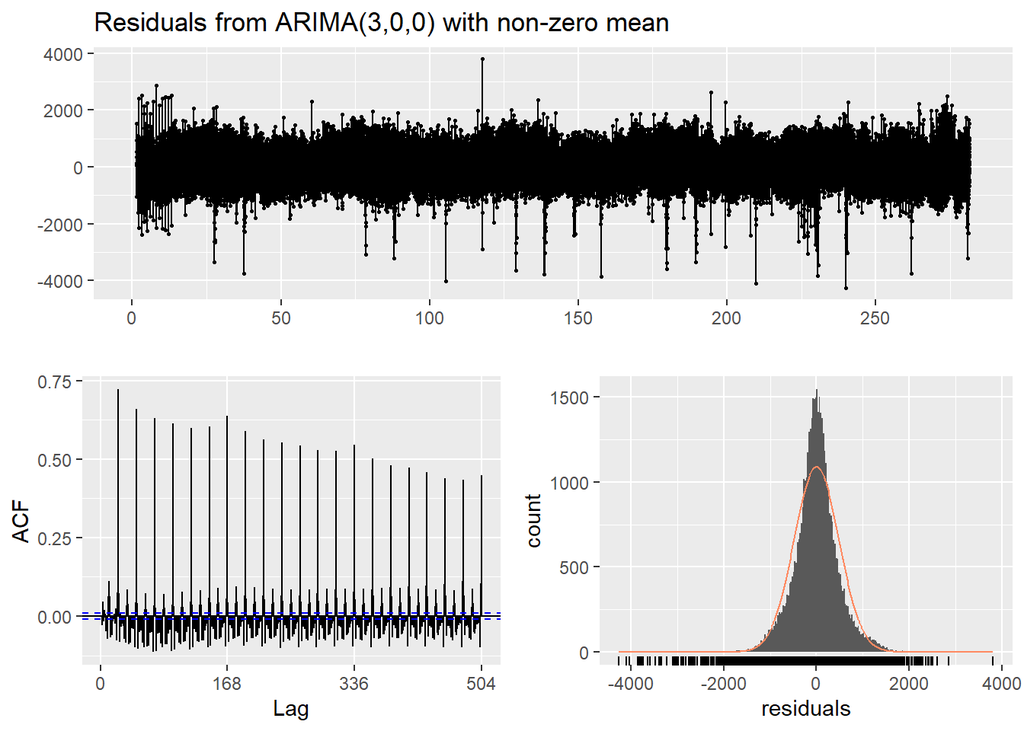

```
##
##  Ljung-Box test
##
## data:  Residuals from ARIMA(3,0,0) with non-zero mean
## Q* = 284482, df = 332, p-value < 2.2e-16
##
## Model df: 4.   Total lags used: 336
```

```r
checkresiduals(ar_model3)
```

```r
ar_model4 = arima(random_hd, order=c(4,0,0))
ar_model4
```

```
##
## Call:
## arima(x = random_hd, order = c(4, 0, 0))
##
## Coefficients:
##          ar1      ar2     ar3      ar4  intercept
##       1.4377  -0.6348  0.1358  -0.0548    -1.0778
## s.e.  0.0046   0.0080  0.0080   0.0046    19.1863
##
## sigma^2 estimated as 233454:  log likelihood = -357472.8,  aic = 714957.6
```

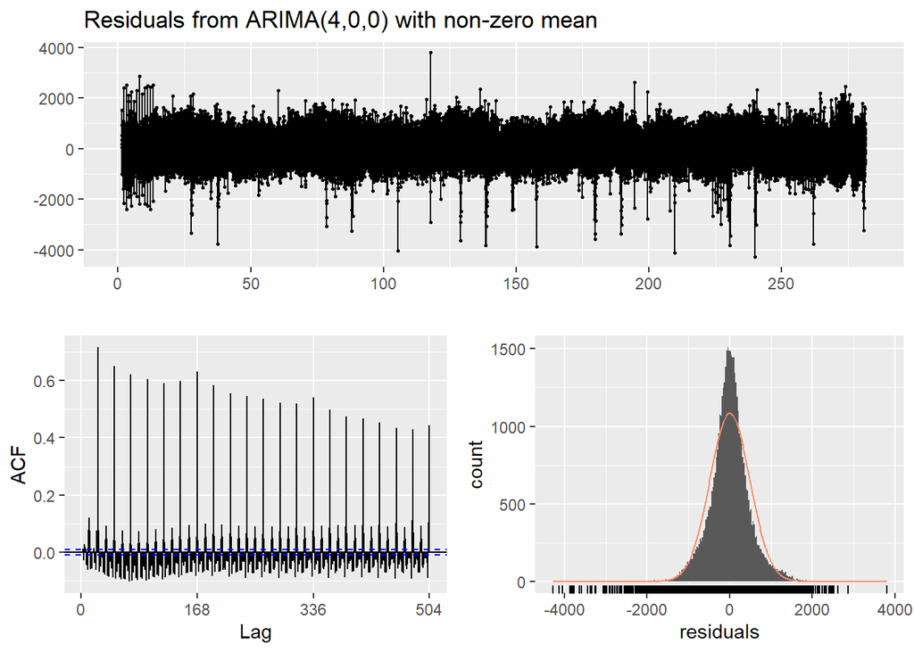

```
##
##  Ljung-Box test
##
## data:  Residuals from ARIMA(4,0,0) with non-zero mean
## Q* = 279680, df = 331, p-value < 2.2e-16
##
## Model df: 5.   Total lags used: 336
```

```r
checkresiduals(ar_model4)
```

```r
ar_model5 = arima(random_hd, order=c(5,0,0))
ar_model5
```

```
##
## Call:
## arima(x = random_hd, order = c(5, 0, 0))
##
## Coefficients:
##          ar1      ar2     ar3      ar4     ar5  intercept
##       1.4386  -0.6371  0.1467  -0.0794  0.0171    -1.0769
## s.e.  0.0046   0.0081  0.0086   0.0081  0.0046    19.5088
##
## sigma^2 estimated as 233386:  log likelihood = -357465.9,  aic = 714945.8
```

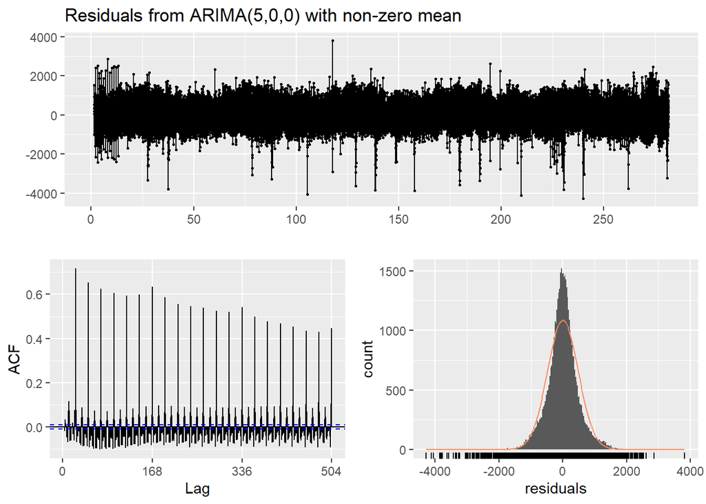

```
##
##  Ljung-Box test
##
## data:  Residuals from ARIMA(5,0,0) with non-zero mean
## Q* = 280495, df = 330, p-value < 2.2e-16
##
## Model df: 6.   Total lags used: 336
```

```r
checkresiduals(ar_model5)
```

## Task 4 (MA Models)

I try to find best MA model.

```r
ar_model = arima(random_hd, order=c(0,0,1))
ar_model
```

```
##
## Call:
## arima(x = random_hd, order = c(0, 0, 1))
##
## Coefficients:
##          ma1  intercept
##       0.8852    -1.0795
## s.e.  0.0015     7.4189
##
## sigma^2 estimated as 728469:  log likelihood = -384237.1,  aic = 768480.1
```

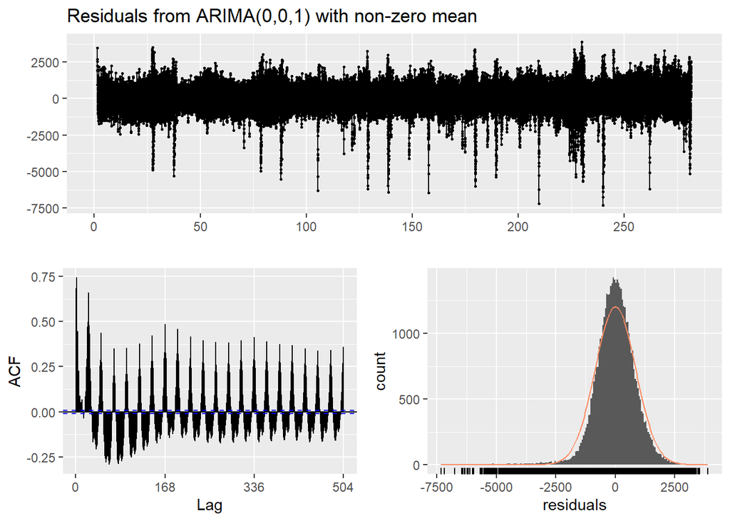

```
##
##  Ljung-Box test
##
## data:  Residuals from ARIMA(0,0,1) with non-zero mean
## Q* = 639927, df = 334, p-value < 2.2e-16
##
## Model df: 2.   Total lags used: 336
```

```r
checkresiduals(ar_model)
```

```r
ar_model2 = arima(random_hd, order=c(0,0,2))
ar_model2
```

```
##
## Call:
## arima(x = random_hd, order = c(0, 0, 2))
##
## Coefficients:
##          ma1     ma2  intercept
##       1.2868  0.6531    -1.0789
## s.e.  0.0033  0.0029     8.7022
##
## sigma^2 estimated as 412167:  log likelihood = -370842.3,  aic = 741692.5
```

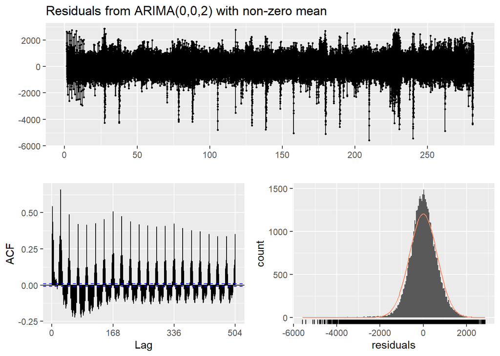

```
##
##  Ljung-Box test
##
## data:  Residuals from ARIMA(0,0,2) with non-zero mean
## Q* = 400412, df = 333, p-value < 2.2e-16
##
## Model df: 3.   Total lags used: 336
```

```r
checkresiduals(ar_model2)
```

```r
ar_model3 = arima(random_hd, order=c(0,0,3))
ar_model3
```

```
##
## Call:
## arima(x = random_hd, order = c(0, 0, 3))
##
## Coefficients:
##          ma1     ma2     ma3  intercept
##       1.3884  1.0927  0.5092    -1.0781
## s.e.  0.0040  0.0047  0.0035    10.1731
##
## sigma^2 estimated as 305786:  log likelihood = -363820.7,  aic = 727651.4
```

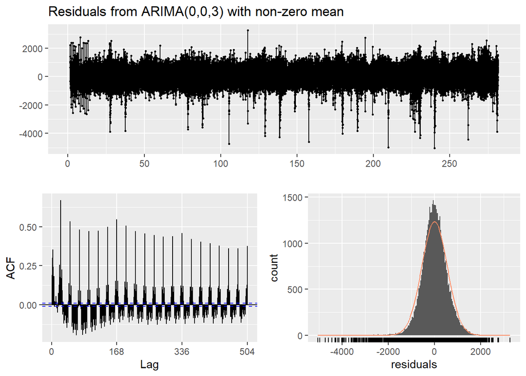

```
##
##  Ljung-Box test
##
## data:  Residuals from ARIMA(0,0,3) with non-zero mean
## Q* = 299683, df = 332, p-value < 2.2e-16
##
## Model df: 4.   Total lags used: 336
```

```r
checkresiduals(ar_model3)
```

```r
ar_model4 = arima(random_hd, order=c(0,0,4))
ar_model4
```

```
##
## Call:
## arima(x = random_hd, order = c(0, 0, 4))
##
## Coefficients:
##          ma1     ma2     ma3     ma4  intercept
##       1.4391  1.2857  0.8489  0.3222    -1.0779
## s.e.  0.0047  0.0068  0.0055  0.0037    11.7014
##
## sigma^2 estimated as 268708:  log likelihood = -360780.5,  aic = 721573
```

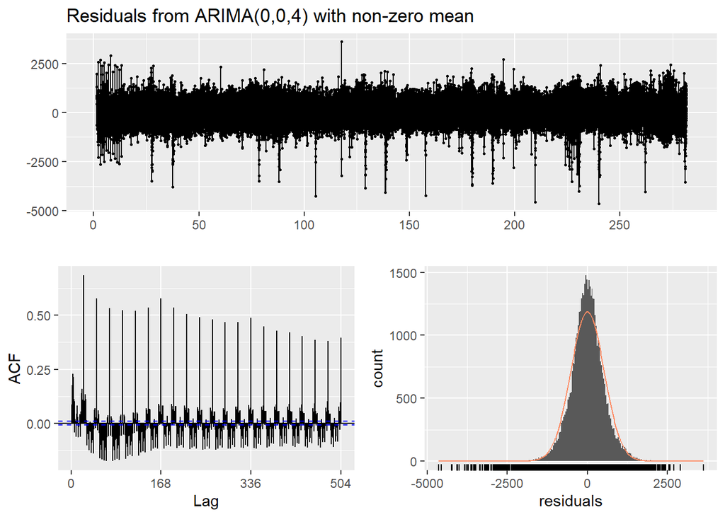

```
##
##  Ljung-Box test
##
## data:  Residuals from ARIMA(0,0,4) with non-zero mean
## Q* = 274351, df = 331, p-value < 2.2e-16
##
## Model df: 5.   Total lags used: 336
```

```r
checkresiduals(ar_model4)
```

```r
ar_model5 = arima(random_hd, order=c(0,0,5))
ar_model5
```

```
##
## Call:
## arima(x = random_hd, order = c(0, 0, 5))
##
## Coefficients:
##          ma1     ma2     ma3     ma4     ma5  intercept
##       1.4422  1.3758  1.1105  0.6845  0.2698    -1.0749
## s.e.  0.0045  0.0072  0.0075  0.0064  0.0040    13.4928
##
## sigma^2 estimated as 247495:  log likelihood = -358846.5,  aic = 717706.9
```

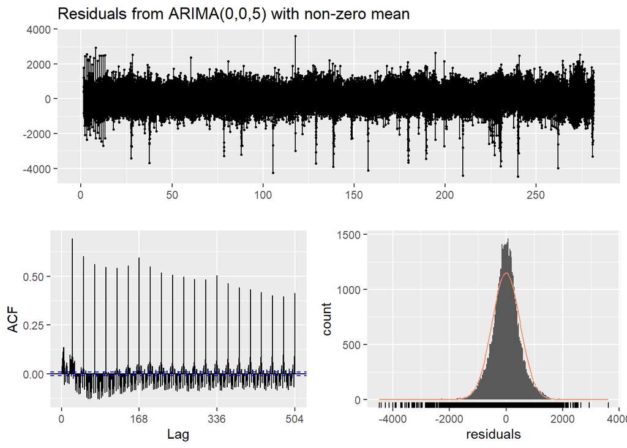

```
##
##  Ljung-Box test
##
## data:  Residuals from ARIMA(0,0,5) with non-zero mean
## Q* = 250303, df = 330, p-value < 2.2e-16
##
## Model df: 6.   Total lags used: 336
```

```r
checkresiduals(ar_model5)
```

Despite the close and high AIC values of the models, the 5th model seems to be the most suitable one.